# Twitter Text Mining

UMaine BUA684 Module 4

Davis Mongare

29 April 2024

# Problem

The aim of this assignment is to, through text mining, develop better understanding of information dissemination about LLBean and its products on Twitter. This task is expected to provide value information to support decision makings on social media marketing.

# Data

## Step 1: Data Collection and Retrieval

```r
# install and load all the needed R packages
# install.packages(c("tidyverse", "tidytext", "wordcloud", "igraph","ggraph", "tidygraph"), repos='http://cran.us.r-project.org')
library(igraph)
library(ggraph)
library(tidyverse)
library(tidytext)
library(wordcloud)
library(igraph)
library(ggraph)
library(tidygraph)
```

```r
# import the Twitter data
LLBean_complete<-read_csv("https://filedn.com/lJpzjOtA91quQEpwdrgCvcy/Business%20Data%20Mining%20and%20Knowledge%20Discovery/Datasets/LLBean.csv")
LLBean_complete<-LLBean_complete %>% filter(language=="en") %>% select(-language)
```

In below, Please write all “your answers” in **Bold** font.

*Problem 1: In the following chunk, use a simple R command to count the total number of Tweet messages contained in the LLBean dataset*

```r
#Total number of Tweet messages
total_tweets <- nrow(LLBean_complete)
total_tweets
```

```
## [1] 239728
```

**Because this Twitter data is too big to be processed on RStudio Cloud, we randomly select a small subset and continue our assignment with the subset**

```r
LLBean<-LLBean_complete %>% sample_n(10000)
LLBean
```

```
## # A tibble: 10,000 × 1
##    tweet
##    <chr>
##  1 #NAME?
##  2 There is no other store that I have more respect for than @LLBean #FavoriteS…
##  3 @Matt_Whitcomb @LLBean That is a big bear!
##  4 @_LLBean 1 ply? Might as well wipe my ass with a dryer sheet. Thin ass tp!!
##  5 .@ThisAmerLife absolutely loved today's episode #591 ! Zoe Chase +  @LLBean …
##  6 So good I had to share! Check out all the items I'm loving on @Poshmarkapp f…
##  7 @amanda_mauder lands end is different than LLBean. ;p
##  8 @WellToDoYou @llbean would totally love to splurge to the shearling lined si…
##  9 #TBT Just another day at the office when the @LLBean Boot parks in front of …
## 10 @LLBean free shipping for the kitten too?  http://t.co/Nfpm4O2ws5
## # … with 9,990 more rows
```

## Step 2: Cleaning and Parsing

### Text Cleaning

```r
LLBean$tweet_clean <- iconv(LLBean$tweet, from="UTF-8", to="ASCII", sub="")
LLBean$tweet_clean <-  gsub("https\\S*", "", LLBean$tweet_clean)
LLBean$tweet_clean <-  gsub("?\\$\\w+ ?", "", LLBean$tweet_clean)
LLBean$tweet_clean <-  gsub("?\\#\\w+ ?", "", LLBean$tweet_clean)
LLBean$tweet_clean <-  gsub("?\\@\\w+ ?", "", LLBean$tweet_clean)
LLBean$tweet_clean <-  gsub("amp", "", LLBean$tweet_clean)
LLBean$tweet_clean <-  gsub("[\r\n]", "", LLBean$tweet_clean)
LLBean$tweet_clean <-  gsub("[[:punct:]]", "", LLBean$tweet_clean)
LLBean$tweet_clean <-  gsub('[[:digit:]]+', "", LLBean$tweet_clean)
LLBean$tweet_clean <-  gsub("(RT|via)((?:\\b\\w*@\\w+)+)","", LLBean$tweet_clean)
LLBean$tweet_clean <- trimws(gsub("\\s+", " ", LLBean$tweet_clean))
```

*Problem 2: Open the “LLBean” dataset in the “Environment” panel (click the Data name in the panel) to compare the column “tweet” with the column “tweet_clean” and then summarize how the above R code clean the tweet messages?**

**Your answer:( The above R code cleaned the data in the following ways:**

- **iconv() function converts the text encoding from UTF-8 to ASCII, ensuring compatibility and removing non-ASCII characters.**
- **The gsub() function with the regular expression https\\S* removes URLs from the tweet messages.**
- **Words starting with a dollar sign (‘$’) are removed using the gsub() function with the regular expression ?\\$\\w+ ?.**
- **Words starting with a hash symbol (‘#’) are removed using the gsub() function with the regular expression ?\\#\\w+ ?.**
- **Words starting with an ‘@’ symbol are removed using the gsub() function with the regular expression ?\\@\\w+ ?.**
- **The string “amp” is removed using the gsub() function.**
- **Newline and carriage return characters are removed using the gsub() function with the regular expression [\r\n].**
- **All punctuation marks are removed using the gsub() function with the regular expression [[:punct:]].**
- **Digits are removed using the gsub() function with the regular expression [[:digit:]]+.**
- **Retweet (“RT”) and via mentions are removed using the gsub() function with the regular expression (RT|via)((?:\\b\\w*@\\w+)+).**
- **Leading and trailing whitespace are removed, and multiple consecutive spaces are collapsed into a single space using the trimws() and gsub() functions.**

  **)**

### Text Parsing (creating the tidy data)

```r
LLBean_tibble <- tibble(line = 1:nrow(LLBean), text = LLBean$tweet_clean)
LLBean_tibble
```

```
## # A tibble: 10,000 × 2
##     line text
##    <int> <chr>
##  1     1 ""
##  2     2 "There is no other store that I have more respect for than"
##  3     3 "That is a big bear"
##  4     4 "ply Might as well wipe my ass with a dryer sheet Thin ass tp"
##  5     5 "absolutely loved todays episode Zoe Chase returns Simon Rich All Amaz…
##  6     6 "So good I had to share Check out all the items Im loving on from"
##  7     7 "lands end is different than LLBean p"
##  8     8 "would totally love to splurge to the shearling lined signature boots …
##  9     9 "Just another day at the office when the Boot parks in front of our ho…
## 10    10 "free shipping for the kitten too httptcoNfpmOws"
## # … with 9,990 more rows
```

```r
LLBean_tidy<-LLBean_tibble%>%unnest_tokens(word, text)
LLBean_tidy
```

```
## # A tibble: 138,715 × 2
##     line word
##    <int> <chr>
##  1     2 there
##  2     2 is
##  3     2 no
##  4     2 other
##  5     2 store
##  6     2 that
##  7     2 i
##  8     2 have
##  9     2 more
## 10     2 respect
## # … with 138,705 more rows
```

# Analysis

## Step 3: Data Analysis and Information Learning

### Word Clouds

```r
# remove all the stop words
words_count<-LLBean_tidy %>%  count(word, sort = TRUE) %>% filter(!word %in% stop_words$word) %>%
                                                           filter(!word %in% c("llbean", "bean", "im", "ll", "check", "size", "items"))
# we are also not interested in some additional terms because they are highly frequent words but conveying less valuable information in the word cloud.
```

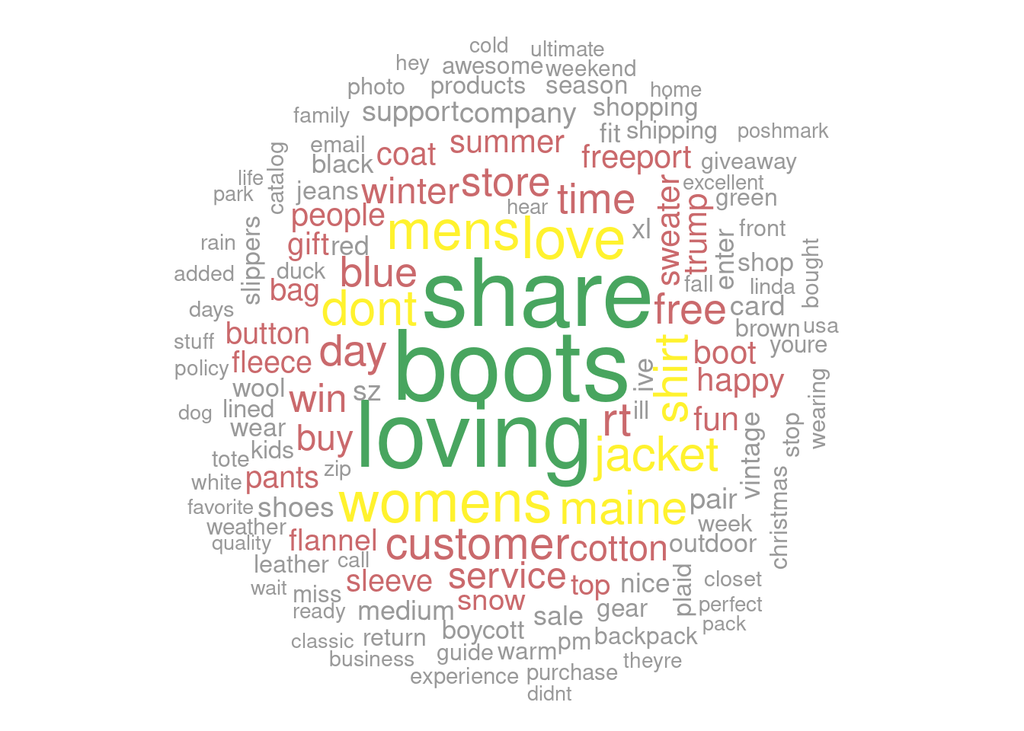

```r
# find 99% percentile of the words_count frequency and create the network visualization only for the top 1% most frequent terms.
q99<-as.integer(quantile(words_count$n, 0.99))
words_count %>% with(wordcloud(word, n, min.freq=q99, random.order=FALSE,
                 colors=rev(colorRampPalette(brewer.pal(9,"Set1"))(32)[seq(8,32,6)])))
```

*Problem 3: What valuable information can you learn from this word cloud?*

**Your answer: (** **Share, Boots,and Loving are the top words , indicating a strong trend of sharing content related to boots.The prominence of Loving suggests positive customer engagement and sentiment towards the LL Bean or specific products.Womens,Mens,don’t,shirt,Maine,Jacket,Shirt,rt Love are also prominet an indication that,the visibility of Mens and Women specific items like Shirt and Jacket suggest that discussions often focus on men’s and women’s apparel, potentially highlighting a strong market segment .Also rt love might indicate a positive reception of the brand.Words like snow,sweater and winter also indicate this conversation is beeing held during Winter season. A keen look also indicates there are customers calling for boycott of the brand with words like boycott making it to the word cloud. )**

### Bi-grams Analysis

```r
LLBean_bigrams<-LLBean_tibble%>%unnest_tokens(bigram, text, token = "ngrams", n = 2)

# separate each pair of two terms into two columns term1 and term2
LLBean_separated <- LLBean_bigrams %>% separate(bigram, c("term1", "term2"), sep = " ")
# remove stop words and one additional word from term1 and term2 columns
LLBean_filtered <- LLBean_separated %>% filter(!term1 %in% stop_words$word) %>%
                                        filter(!term2 %in% stop_words$word) %>%
                                        filter(!term1 %in% c("size")) %>%
                                        filter(!term2 %in% c("size"))
```

### Term Association

```r
# find the second terms most frequently following “llbean”
LLBean_filtered  %>%  filter(term1 == "llbean") %>% count(term2, sort = TRUE)
```

```
## # A tibble: 577 × 2
##    term2         n
##    <chr>     <int>
##  1 boots        41
##  2 slippers     22
##  3 backpack     20
##  4 freeport     17
##  5 catalog      16
##  6 wagon        16
##  7 signature    15
##  8 flannel      13
##  9 store        13
## 10 visa         13
## # … with 567 more rows
```

*Problem 4: What valuable information can you learn from the term associations summarized above?*

```r
# find the first terms most frequently followed by “llbean”
LLBean_filtered  %>%  filter(term2 == "llbean") %>% count(term1, sort = TRUE)
```

```
## # A tibble: 346 × 2
##    term1           n
##    <chr>       <int>
##  1 poshmark       55
##  2 love           23
##  3 outback        19
##  4 boycott        18
##  5 buy            17
##  6 rt             13
##  7 monogrammed     8
##  8 zappos          7
##  9 vintage         6
## 10 green           5
## # … with 336 more rows
```

*Problem 5: What valuable information can you learn from the term associations summarized above?*

**boycott points to potential reputation challenges LL Bean is facing. Vintage indicates an appreciation for L.L.Bean’s classic products, shop and support point to an active shopping behavior and aimed at supporting the brand.**

**Outback might be and indication of customers preference or association** **to LL Bean products for outdoor activities.**

**)**

### Semantic Network Analysis

```r
# we further filter out "llbean" since it is well expected to be a major hub but does not convery very valuable information
LLBean_filtered_SNA<-LLBean_filtered  %>% filter(!term1 %in% c("llbean", "ll", "bean")) %>%
                                         filter(!term2 %in% c("llbean", "ll", "bean"))
LLBean_filtered_SNA_count<-LLBean_filtered_SNA  %>%  count(term1, term2, sort = TRUE)
```

#### Automated Network Creation

```r
# find 99% percentile of the bigrams frequency and create the network visualization only for the top 1% most frequent bigrams.
q99<-as.integer(quantile(LLBean_filtered_SNA_count$n, 0.99))
LLBean_filtered_SNA_count_top<-LLBean_filtered_SNA_count %>% filter(n > q99)
nrow(LLBean_filtered_SNA_count_top)
```

```
## [1] 187
```

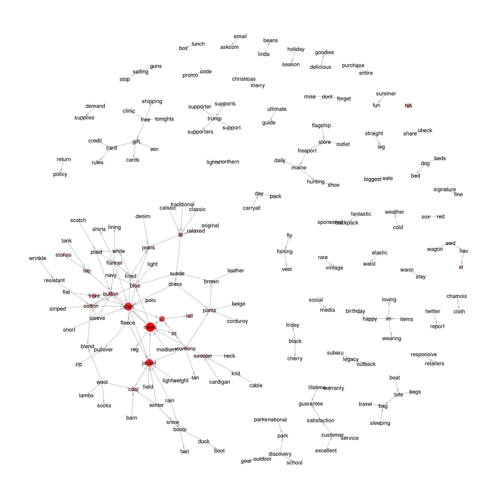

```r
set.seed(2023)
# this function normalize any scale into a scale of 0 to 1
normalize <- function (x, from = range(x), to = c(0, 1)) {
  x <- (x - from[1])/(from[2] - from[1])
  if (!identical(to, c(0, 1))) {
    x <- x * (to[2] - to[1]) + to[1]
  }
  x
}

# create the graph for top bigrams and add popularity of node
bigram_graph <- as_tbl_graph(LLBean_filtered_SNA_count_top) %>%
    # calculate pagerank centrality score as the popularity
    mutate(Popularity = centrality_pagerank())


# normalize the popularity value for better visualization effect
V(bigram_graph)$Popularity <- normalize(V(bigram_graph)$Popularity, to = c(1, 8))

# create semantic network visualization
ggraph(bigram_graph, "fr") +
  geom_edge_link(
    aes(end_cap = circle(node2.Popularity + 2, "pt")),
    edge_colour = "gray",
    arrow = arrow(
    angle = 10,
    length = unit(0.1, "inches"),
    ends = "last",
    type = "closed")
  ) +
  geom_node_point(
    aes(size= I(Popularity), alpha=Popularity),
    col = "red",
    show.legend = FALSE
  ) +geom_node_text(aes(label = name))+
  theme_graph()
```

#### Semantic Analysis

*Problem 6: What valuable information can you learn from the semantic network created above?* (**after knitting the file to a html file, set the browser zoom level to 200% or even higher for better visibility**)

**Hint:** *Which nodes are the top hubs based on their PageRank score. Then, how are these top hubs connected with one another through some interesting paths passing through several other nodes? Also, are there other interesting paths passing through some nodes in this network?*

**I find the field path to be interesting as its associated with Jackets and potentially pointing to the jackets being popular to customers who work in fields. )**

# Discussion

*Reflect on the ways in which the text mining results could contribute to the development of an enhanced social media marketing strategy for the company. Although this analysis won’t be detailed here, you will have the opportunity to collaborate with your project team, allowing you to work together with your teammates to further examine this aspect and devise comprehensive marketing approaches.*

**I believe text mining techniques such as word clouds, n-grams analysis, and semantic network analysis could significantly contribute to the development of an enhanced social media marketing strategy for the company.Word clouds, for instance, could help visualize the most frequent topics in customer conversations, guiding the content strategy to focus on what customers care about the most. I think using these insights can make social media content more relevant and engaging to the audience.N-grams analysis could provide a deeper understanding of the language customers use when talking about the company’s products. I believe incorporating these phrases into social media posts and advertising can create a sense of familiarity and trust with the audience.Semantic network analysis, in my view, could offer a map of how different topics related to the company are interconnected. I think this could be particularly useful for crafting a narrative that aligns with the customer’s journey and interests, weaving together related concepts that matter to them.Incorporating these data-driven insights, I believe, could lead to a more organic and effective social media presence. The company’s marketing content could become a natural part of the customer’s online discourse, potentially enhancing engagement and customer loyalty.**